# Multiple Linear Regression in R

Bruno Dos Santos

# Introduction

In this Notebook, we present the methodology that we used to perform a multiple linear regression. We use data from [Kaggle](https://www.kaggle.com/datasets/harlfoxem/housesalesprediction), named *“House Sales in King County, USA”*, to predict house price using a regression model. The data set contains house sales prices for King County, which includes Seattle. It includes homes sold between May 2014 and May 2015, with 21,613 registers and 21 variables regarding the houses sold.

## R notebook

Load R packages used in this notebook:

```r
library("here")
library("MASS")
library("lmtest")
library("psych")
library("regclass")
```

Reading the housing data set and creating a data frame:

```r
df <- as.data.frame(read.csv(here("data-raw","kc_house_data.csv")))
```

Visualizing the first five lines of the data frame:

```r
head(df,5)
```

|  | id | date | price | bedrooms | bathrooms | sqft_living | sqft_lot | floors | waterfront | view | condition | grade | sqft_above | sqft_basement | yr_built | yr_renovated | zipcode | lat | long | sqft_living15 | sqft_lot15 |
| --- | --- | --- | --- | --- | --- | --- | --- | --- | --- | --- | --- | --- | --- | --- | --- | --- | --- | --- | --- | --- | --- |
| 1 | 7129300520 | 20141013T000000 | 221900 | 3 | 1.00 | 1180 | 5650 | 1 | 0 | 0 | 3 | 7 | 1180 | 0 | 1955 | 0 | 98178 | 47.5112 | -122.257 | 1340 | 5650 |
| 2 | 6414100192 | 20141209T000000 | 538000 | 3 | 2.25 | 2570 | 7242 | 2 | 0 | 0 | 3 | 7 | 2170 | 400 | 1951 | 1991 | 98125 | 47.7210 | -122.319 | 1690 | 7639 |
| 3 | 5631500400 | 20150225T000000 | 180000 | 2 | 1.00 | 770 | 10000 | 1 | 0 | 0 | 3 | 6 | 770 | 0 | 1933 | 0 | 98028 | 47.7379 | -122.233 | 2720 | 8062 |
| 4 | 2487200875 | 20141209T000000 | 604000 | 4 | 3.00 | 1960 | 5000 | 1 | 0 | 0 | 5 | 7 | 1050 | 910 | 1965 | 0 | 98136 | 47.5208 | -122.393 | 1360 | 5000 |
| 5 | 1954400510 | 20150218T000000 | 510000 | 3 | 2.00 | 1680 | 8080 | 1 | 0 | 0 | 3 | 8 | 1680 | 0 | 1987 | 0 | 98074 | 47.6168 | -122.045 | 1800 | 7503 |

The variable `ID` will not be used to perform the regression model, so we will remove if from the data set. Also, the variable date, regarding the date of house sell, does not bring much information because the time range is a few higher than 1 year, so we’ll exclude it too. The next chuck select only the variables that we will use for modelling:

```r
df <- df[,3:21]
```

Visualizing some statistics about the data:

```r
summary(df)
```

```
     price            bedrooms        bathrooms
 Min.   :  75000   Min.   : 0.000   Min.   :0.000
 1st Qu.: 321950   1st Qu.: 3.000   1st Qu.:1.750
 Median : 450000   Median : 3.000   Median :2.250
 Mean   : 540088   Mean   : 3.371   Mean   :2.115
 3rd Qu.: 645000   3rd Qu.: 4.000   3rd Qu.:2.500
 Max.   :7700000   Max.   :33.000   Max.   :8.000
  sqft_living       sqft_lot           floors
 Min.   :  290   Min.   :    520   Min.   :1.000
 1st Qu.: 1427   1st Qu.:   5040   1st Qu.:1.000
 Median : 1910   Median :   7618   Median :1.500
 Mean   : 2080   Mean   :  15107   Mean   :1.494
 3rd Qu.: 2550   3rd Qu.:  10688   3rd Qu.:2.000
 Max.   :13540   Max.   :1651359   Max.   :3.500
   waterfront            view          condition
 Min.   :0.000000   Min.   :0.0000   Min.   :1.000
 1st Qu.:0.000000   1st Qu.:0.0000   1st Qu.:3.000
 Median :0.000000   Median :0.0000   Median :3.000
 Mean   :0.007542   Mean   :0.2343   Mean   :3.409
 3rd Qu.:0.000000   3rd Qu.:0.0000   3rd Qu.:4.000
 Max.   :1.000000   Max.   :4.0000   Max.   :5.000
     grade          sqft_above   sqft_basement
 Min.   : 1.000   Min.   : 290   Min.   :   0.0
 1st Qu.: 7.000   1st Qu.:1190   1st Qu.:   0.0
 Median : 7.000   Median :1560   Median :   0.0
 Mean   : 7.657   Mean   :1788   Mean   : 291.5
 3rd Qu.: 8.000   3rd Qu.:2210   3rd Qu.: 560.0
 Max.   :13.000   Max.   :9410   Max.   :4820.0
    yr_built     yr_renovated       zipcode
 Min.   :1900   Min.   :   0.0   Min.   :98001
 1st Qu.:1951   1st Qu.:   0.0   1st Qu.:98033
 Median :1975   Median :   0.0   Median :98065
 Mean   :1971   Mean   :  84.4   Mean   :98078
 3rd Qu.:1997   3rd Qu.:   0.0   3rd Qu.:98118
 Max.   :2015   Max.   :2015.0   Max.   :98199
      lat             long        sqft_living15
 Min.   :47.16   Min.   :-122.5   Min.   : 399
 1st Qu.:47.47   1st Qu.:-122.3   1st Qu.:1490
 Median :47.57   Median :-122.2   Median :1840
 Mean   :47.56   Mean   :-122.2   Mean   :1987
 3rd Qu.:47.68   3rd Qu.:-122.1   3rd Qu.:2360
 Max.   :47.78   Max.   :-121.3   Max.   :6210
   sqft_lot15
 Min.   :   651
 1st Qu.:  5100
 Median :  7620
 Mean   : 12768
 3rd Qu.: 10083
 Max.   :871200
```

Now, let’s exclude possible missing values. First, we’ll count the row number of our data frame:

```r
nrow(df)
```

```
[1] 21613
```

Now, we’ll exclude the missing values (NA values), and then, count the row number again:

```r
df <- na.omit(df)
nrow(df)
```

```
[1] 21613
```

The number didn’t change, which means that there were no missing values in our data frame. Visualizing the type of the variables:

```r
str(df)
```

```
'data.frame':   21613 obs. of  19 variables:
 $ price        : num  221900 538000 180000 604000 510000 ...
 $ bedrooms     : int  3 3 2 4 3 4 3 3 3 3 ...
 $ bathrooms    : num  1 2.25 1 3 2 4.5 2.25 1.5 1 2.5 ...
 $ sqft_living  : int  1180 2570 770 1960 1680 5420 1715 1060 1780 1890 ...
 $ sqft_lot     : int  5650 7242 10000 5000 8080 101930 6819 9711 7470 6560 ...
 $ floors       : num  1 2 1 1 1 1 2 1 1 2 ...
 $ waterfront   : int  0 0 0 0 0 0 0 0 0 0 ...
 $ view         : int  0 0 0 0 0 0 0 0 0 0 ...
 $ condition    : int  3 3 3 5 3 3 3 3 3 3 ...
 $ grade        : int  7 7 6 7 8 11 7 7 7 7 ...
 $ sqft_above   : int  1180 2170 770 1050 1680 3890 1715 1060 1050 1890 ...
 $ sqft_basement: int  0 400 0 910 0 1530 0 0 730 0 ...
 $ yr_built     : int  1955 1951 1933 1965 1987 2001 1995 1963 1960 2003 ...
 $ yr_renovated : int  0 1991 0 0 0 0 0 0 0 0 ...
 $ zipcode      : int  98178 98125 98028 98136 98074 98053 98003 98198 98146 98038 ...
 $ lat          : num  47.5 47.7 47.7 47.5 47.6 ...
 $ long         : num  -122 -122 -122 -122 -122 ...
 $ sqft_living15: int  1340 1690 2720 1360 1800 4760 2238 1650 1780 2390 ...
 $ sqft_lot15   : int  5650 7639 8062 5000 7503 101930 6819 9711 8113 7570 ...
```

All the variables in our data frame are numeric or integer, which means that we don’t need to apply any process to convert the data type in order to run the regression model.

## Regression models

Let’s perform the first regression model. In this case, we will use all variables of the data set to predict the price of the house:

```r
model_lr1 <- lm(df$price ~ . , data = df)
```

Let’s visualize some information about our first model:

```r
summary(model_lr1)
```

```
Call:
lm(formula = df$price ~ ., data = df)

Residuals:
     Min       1Q   Median       3Q      Max
-1224709   -98347   -10755    75516  3301803

Coefficients: (1 not defined because of singularities)
                Estimate Std. Error t value Pr(>|t|)
(Intercept)    5.789e+06  2.824e+06   2.050  0.04040 *
bedrooms      -3.478e+04  1.901e+03 -18.302  < 2e-16 ***
bathrooms      3.989e+04  3.142e+03  12.697  < 2e-16 ***
sqft_living    1.387e+02  4.251e+00  32.615  < 2e-16 ***
sqft_lot       1.466e-01  4.613e-02   3.179  0.00148 **
floors         1.010e+04  3.466e+03   2.915  0.00356 **
waterfront     5.406e+05  1.693e+04  31.925  < 2e-16 ***
view           5.235e+04  2.064e+03  25.368  < 2e-16 ***
condition      2.735e+04  2.265e+03  12.074  < 2e-16 ***
grade          9.855e+04  2.077e+03  47.458  < 2e-16 ***
sqft_above     2.586e+01  4.204e+00   6.152 7.79e-10 ***
sqft_basement         NA         NA      NA       NA
yr_built      -2.572e+03  7.000e+01 -36.738  < 2e-16 ***
yr_renovated   1.906e+01  3.522e+00   5.411 6.34e-08 ***
zipcode       -5.640e+02  3.178e+01 -17.750  < 2e-16 ***
lat            6.000e+05  1.034e+04  58.011  < 2e-16 ***
long          -2.075e+05  1.265e+04 -16.408  < 2e-16 ***
sqft_living15  3.045e+01  3.328e+00   9.150  < 2e-16 ***
sqft_lot15    -3.624e-01  7.058e-02  -5.134 2.85e-07 ***
---
Signif. codes:
0 ‘***’ 0.001 ‘**’ 0.01 ‘*’ 0.05 ‘.’ 0.1 ‘ ’ 1

Residual standard error: 193700 on 21557 degrees of freedom
Multiple R-squared:  0.704, Adjusted R-squared:  0.7037
F-statistic:  3015 on 17 and 21557 DF,  p-value: < 2.2e-16
```

```r
model_lr2 <- stepAIC(model_lr1, direction = "both", trace = 1)
```

```
Start:  AIC=525323.9
df$price ~ bedrooms + bathrooms + sqft_living + sqft_lot + floors +
    waterfront + view + condition + grade + sqft_above + sqft_basement +
    yr_built + yr_renovated + zipcode + lat + long + sqft_living15 +
    sqft_lot15


Step:  AIC=525323.9
df$price ~ bedrooms + bathrooms + sqft_living + sqft_lot + floors +
    waterfront + view + condition + grade + sqft_above + yr_built +
    yr_renovated + zipcode + lat + long + sqft_living15 + sqft_lot15

                Df  Sum of Sq        RSS    AIC
<none>                        8.0862e+14 525324
- floors         1 3.1878e+11 8.0894e+14 525330
- sqft_lot       1 3.7900e+11 8.0900e+14 525332
- sqft_lot15     1 9.8889e+11 8.0961e+14 525348
- yr_renovated   1 1.0982e+12 8.0972e+14 525351
- sqft_above     1 1.4196e+12 8.1004e+14 525360
- sqft_living15  1 3.1408e+12 8.1176e+14 525405
- condition      1 5.4688e+12 8.1409e+14 525467
- bathrooms      1 6.0470e+12 8.1467e+14 525483
- long           1 1.0099e+13 8.1872e+14 525590
- zipcode        1 1.1818e+13 8.2044e+14 525635
- bedrooms       1 1.2564e+13 8.2119e+14 525655
- view           1 2.4139e+13 8.3276e+14 525956
- waterfront     1 3.8232e+13 8.4685e+14 526319
- sqft_living    1 3.9901e+13 8.4852e+14 526361
- yr_built       1 5.0628e+13 8.5925e+14 526632
- grade          1 8.4483e+13 8.9310e+14 527466
- lat            1 1.2623e+14 9.3486e+14 528452
```

Let’s visualize some information about our second model:

```r
summary(model_lr2)
```

```
Call:
lm(formula = df$price ~ bedrooms + bathrooms + sqft_living +
    sqft_lot + floors + waterfront + view + condition + grade +
    sqft_above + yr_built + yr_renovated + zipcode + lat + long +
    sqft_living15 + sqft_lot15, data = df)

Residuals:
     Min       1Q   Median       3Q      Max
-1224709   -98347   -10755    75516  3301803

Coefficients:
                Estimate Std. Error t value Pr(>|t|)
(Intercept)    5.789e+06  2.824e+06   2.050  0.04040 *
bedrooms      -3.478e+04  1.901e+03 -18.302  < 2e-16 ***
bathrooms      3.989e+04  3.142e+03  12.697  < 2e-16 ***
sqft_living    1.387e+02  4.251e+00  32.615  < 2e-16 ***
sqft_lot       1.466e-01  4.613e-02   3.179  0.00148 **
floors         1.010e+04  3.466e+03   2.915  0.00356 **
waterfront     5.406e+05  1.693e+04  31.925  < 2e-16 ***
view           5.235e+04  2.064e+03  25.368  < 2e-16 ***
condition      2.735e+04  2.265e+03  12.074  < 2e-16 ***
grade          9.855e+04  2.077e+03  47.458  < 2e-16 ***
sqft_above     2.586e+01  4.204e+00   6.152 7.79e-10 ***
yr_built      -2.572e+03  7.000e+01 -36.738  < 2e-16 ***
yr_renovated   1.906e+01  3.522e+00   5.411 6.34e-08 ***
zipcode       -5.640e+02  3.178e+01 -17.750  < 2e-16 ***
lat            6.000e+05  1.034e+04  58.011  < 2e-16 ***
long          -2.075e+05  1.265e+04 -16.408  < 2e-16 ***
sqft_living15  3.045e+01  3.328e+00   9.150  < 2e-16 ***
sqft_lot15    -3.624e-01  7.058e-02  -5.134 2.85e-07 ***
---
Signif. codes:
0 ‘***’ 0.001 ‘**’ 0.01 ‘*’ 0.05 ‘.’ 0.1 ‘ ’ 1

Residual standard error: 193700 on 21557 degrees of freedom
Multiple R-squared:  0.704, Adjusted R-squared:  0.7037
F-statistic:  3015 on 17 and 21557 DF,  p-value: < 2.2e-16
```

According to the summary above, all coefficients are significant. We can check the value of the R-squared, a statistical measure that determines the proportion of variance in the dependent variable that can be explained by the independent variables.

## Diagnosing the regression model

Let’s use some diagnostic plots about our regression model (model 2).

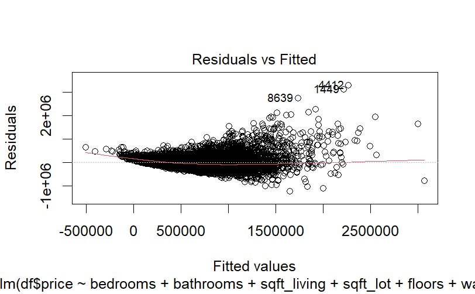

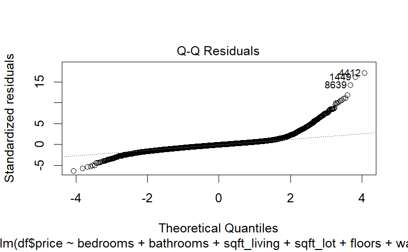

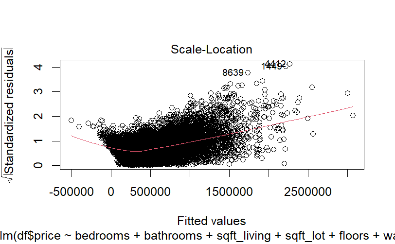

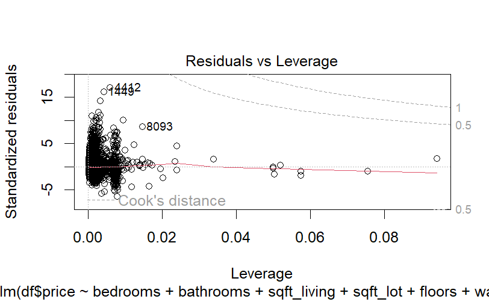

```r
plot(model_lr2)
```

```r
df <- df[-c(3915,7253,9255,15871,4412,1316,1165,1449,8639),]
```

**📝 *After remove the abnormal points, we need to perform the regression model section again.***

```r
#shapiro.test(model_lr2$residuals)
```

We can use the summary of standard residuals to evaluate the existence of outliers. The minimum and maximum values must have similar absolute values, the mean must be close to zero and the first and third quartiles must have similar absolute values too:

```r
summary(rstandard(model_lr2))
```

```
     Min.   1st Qu.    Median      Mean   3rd Qu.      Max.
-6.348604 -0.508034 -0.055540  0.000029  0.389987 17.099018
```

The Breusch-Pagan test evaluates the homoscedasticity of the residuals. To prove the homoscedasticity, the p-value must be higher than 0.05:

```r
bptest(model_lr2)
```

```
    studentized Breusch-Pagan test

data:  model_lr2
BP = 3042.6, df = 17, p-value < 2.2e-16
```

The VIF test evaluates the multicolinarity between the independent variables. In this case, all variables must have a VIF value less than 10:

```r
VIF(model_lr2)
```

```
     bedrooms     bathrooms   sqft_living      sqft_lot
     1.711166      3.344558      8.632340      2.100265
       floors    waterfront          view     condition
     2.014154      1.199008      1.429239      1.249678
        grade    sqft_above      yr_built  yr_renovated
     3.415408      6.897707      2.432826      1.149242
      zipcode           lat          long sqft_living15
     1.662787      1.181304      1.824927      2.986059
   sqft_lot15
     2.133377
```

After apllying the test, we can see that our residuals don’t present normality and homoscedasticity. In future applications, we can apply some process to correct this. For the non-normality residuals, we can make transformations to dependent variable and keep removing outliers. For the heteroscedasticity, we can implement other types of regressions or data transformations. Also, the model would be beneficied if the data be splitted into training and test data for modelling.

Finally, we will compare the predicted values with the true values using a scatter plot. In a good model, the predicted values must be close to the blue line:

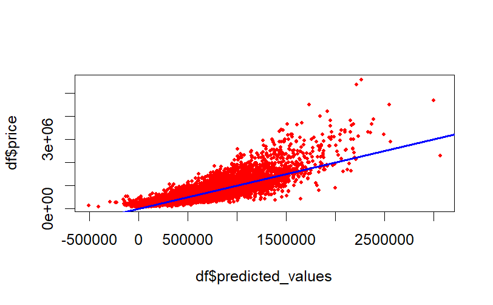

```r
df$predicted_values <- model_lr2$fitted.values

p <- plot(df$predicted_values, df$price, col='red', cex = 0.5, pch = 19)
p <- p + abline(lm(df$price~df$predicted_values), lwd=2,col='blue')
```

```r
p
```

```
integer(0)
```

Finally, we will save our data frame in the data folder:

```r
kc_house_data_processed <- df

usethis::use_data(kc_house_data_processed, overwrite = TRUE)
```